# CSDE Workshop: Introduction to R

Deven Hamilton

October 23, 2025

# Getting started

## Download R

What is `R`? Open-source, free, statistical computing software.

Go to the [R website](https://cran.r-project.org/), and download the appropriate software for your operating system.

[figure not shown]

## Download RStudio

What is Rstudio? A nice GUI (graphical user interface) for writing code, analyzing data and building packages with `R`.

Go to the [RStudio website](https://rstudio.com/products/rstudio/download/#download). and download the appropriate software for your operating system.

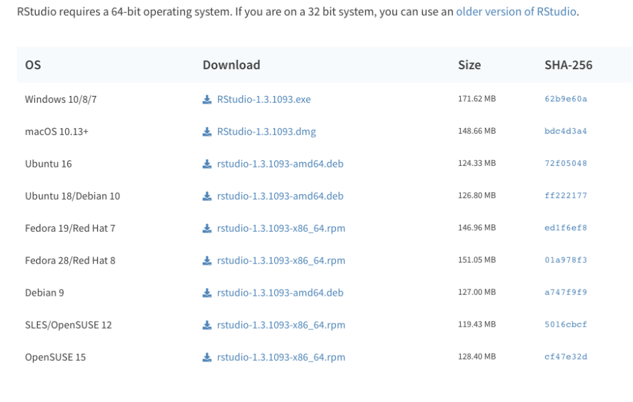

## Rstudio Layout

Rstudio has four main panels that allow you to organize your code and have a better user experience developing and using `R` code:

- Source panel: where scripts are edited
- Console panel: where code is executed and output is printed
- Environment panel: where objects are stored
- Files/Plots/Help: navigate files and folders, view plots, read and access help documentation for packages and functions

[figure not shown]

# R Packages

R is open source software meaning that anyone can contribute to the development of the software. Contributors can submit R packages to CRAN, upload them to public repositories like github, or host them on their own systems. An R package is a collection of R functions, data, and documentation that extends the functionality of the R statistical programming language for a specific task.

We are going to download some useful R packages that we will use later in the course.

- Go to the tools drop down menu and select “install packages”.
- In the pop-up window make sure that the “Install dependencies” box in checked.
- Type “tidyverse” in the packages field and click install.
- In the console window type library(tidyverse) to load the tidyverse package in to your working environment.

You will use the same procedure to load any packages you may want to use in the future for sample weighting, Bayesian statistics, spacial analysis, network modeling etc.

Now open a new .R script by clicking File $\rightarrow$ New File $\rightarrow$ R Script.

[figure not shown]

# R as a calculator

We can execute code by typing it directly into the console and pressing enter.

[figure not shown]

We can also execute code by highlighting it in a source file and clicking the run button. Try entering 2+3 in the R script, highlighting it, and running it.

```r
2+3
```

```
## [1] 5
```

We can do basic mathematical computations using +,-, *, /, and ().

Note: `pi` is hard coded into `R`.

```r
2+3
```

```
## [1] 5
```

```r
6*7
```

```
## [1] 42
```

```r
pi*1
```

```
## [1] 3.141593
```

```r
6*3/2-3
```

```
## [1] 6
```

```r
6*3/(2-3)
```

```
## [1] -18
```

```r
1/0
```

```
## [1] Inf
```

Try some on your own!

What about more complicated functions like exponents, square roots, trig functions and the natural logarithm?

```r
3^2
```

```
## [1] 9
```

```r
2^(3+2)
```

```
## [1] 32
```

```r
sqrt(9)
```

```
## [1] 3
```

```r
sin(2*pi)
```

```
## [1] -2.449213e-16
```

```r
log(1000)
```

```
## [1] 6.907755
```

```r
exp(6.907755)
```

```
## [1] 999.9997
```

Note: {log()} computes the natural logarithm by default.

# Documentation

One convenient feature in {R} is the documentation for all functions. If you want to learn more about a function and its arguments you can simply type a question mark in front of the function name or use the {help()} function. See {?log} to compute a logarithm with a different base.

```r
?log
help("log")
```

**Question** According to the above help files, what function (or functions) would you need to use for a base 10 logarithm?

There are a few other functions that can help you understand how to use functions or recall their arguments.

```r
help.search("log")
args(log)
```